# Bagging and Random Forest

```r
library(ISLR2)
library(data.table)
library(randomForest)
library(caret)

set.seed(1234)
data <- Boston
head(data)
```

|  | crim | zn | indus | chas | nox | rm | age | dis | rad | tax | ptratio | lstat | medv |
| --- | --- | --- | --- | --- | --- | --- | --- | --- | --- | --- | --- | --- | --- |
| 1 | 0.00632 | 18 | 2.31 | 0 | 0.538 | 6.575 | 65.2 | 4.0900 | 1 | 296 | 15.3 | 4.98 | 24.0 |
| 2 | 0.02731 | 0 | 7.07 | 0 | 0.469 | 6.421 | 78.9 | 4.9671 | 2 | 242 | 17.8 | 9.14 | 21.6 |
| 3 | 0.02729 | 0 | 7.07 | 0 | 0.469 | 7.185 | 61.1 | 4.9671 | 2 | 242 | 17.8 | 4.03 | 34.7 |
| 4 | 0.03237 | 0 | 2.18 | 0 | 0.458 | 6.998 | 45.8 | 6.0622 | 3 | 222 | 18.7 | 2.94 | 33.4 |
| 5 | 0.06905 | 0 | 2.18 | 0 | 0.458 | 7.147 | 54.2 | 6.0622 | 3 | 222 | 18.7 | 5.33 | 36.2 |
| 6 | 0.02985 | 0 | 2.18 | 0 | 0.458 | 6.430 | 58.7 | 6.0622 | 3 | 222 | 18.7 | 5.21 | 28.7 |

Partition the data

```r
intrain1<-createDataPartition(y=data$medv, p=0.8, list=FALSE)
train_data1 <- data[intrain1, ]
test_data1 <- data[-intrain1, ]
```

Set up Crossvalidation

```r
reg_control <-trainControl(method="cv", number = 10)
```

## Bagging

```r
bag_boston <- randomForest(medv ~ ., data = train_data1, mtry = 12)
bag_boston
```

```
Call:
 randomForest(formula = medv ~ ., data = train_data1, mtry = 12)
               Type of random forest: regression
                     Number of trees: 500
No. of variables tried at each split: 12

          Mean of squared residuals: 12.07642
                    % Var explained: 86.52
```

The argument mtry=12 indicates that all 12 predictors should be considered for each split of the tree - in other words bagging should be done.

Let us check the performance of this model on the test data

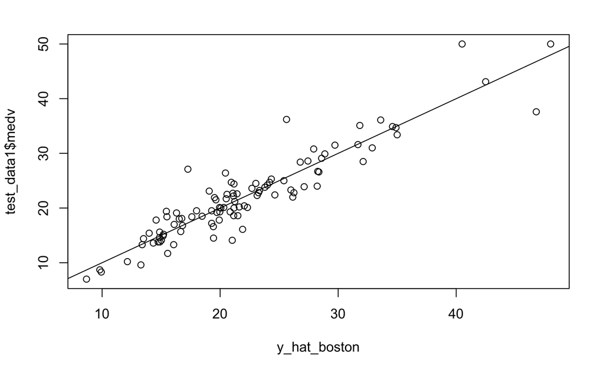

```r
y_hat_boston <- predict(bag_boston, test_data1)
plot(y_hat_boston, test_data1$medv)
abline(0, 1)
```

```r
mean(y_hat_boston - test_data1$medv)^2
```

```
[1] 0.0001567344
```

We can change the number of trees by using the ntree argument.

```r
bag_boston <- randomForest(medv ~ ., data = train_data1, mtry = 12, ntree = 25)
bag_boston
```

```
Call:
 randomForest(formula = medv ~ ., data = train_data1, mtry = 12,      ntree = 25)
               Type of random forest: regression
                     Number of trees: 25
No. of variables tried at each split: 12

          Mean of squared residuals: 14.93191
                    % Var explained: 83.33
```

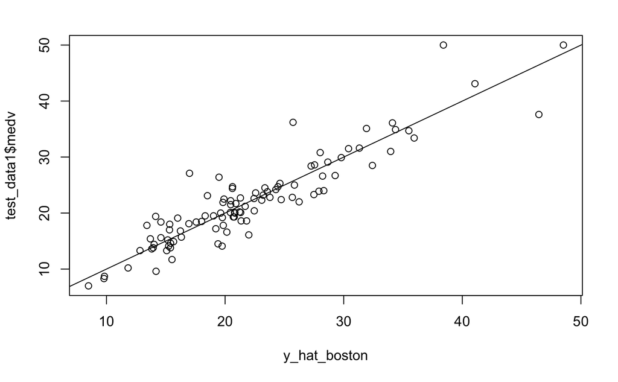

```r
y_hat_boston <- predict(bag_boston, test_data1)
plot(y_hat_boston, test_data1$medv)
abline(0, 1)
```

```r
mean(y_hat_boston - test_data1$medv)^2
```

```
[1] 0.0001159574
```

## Random Forest

Growing a random forest tree proceeds exactly in the same way, except that we use a smaller value for mtry. By default, randomForest() uses p/3 variables when building a random forest of regression trees and sqrt(p) variables when building a random forest of classification trees.

Let us try a random forest with mtry = 6

```r
rf_boston <- randomForest(medv ~ ., data = train_data1, mtry = 6, importance = TRUE)
rf_boston
```

```
Call:
 randomForest(formula = medv ~ ., data = train_data1, mtry = 6,      importance = TRUE)
               Type of random forest: regression
                     Number of trees: 500
No. of variables tried at each split: 6

          Mean of squared residuals: 10.88556
                    % Var explained: 87.85
```

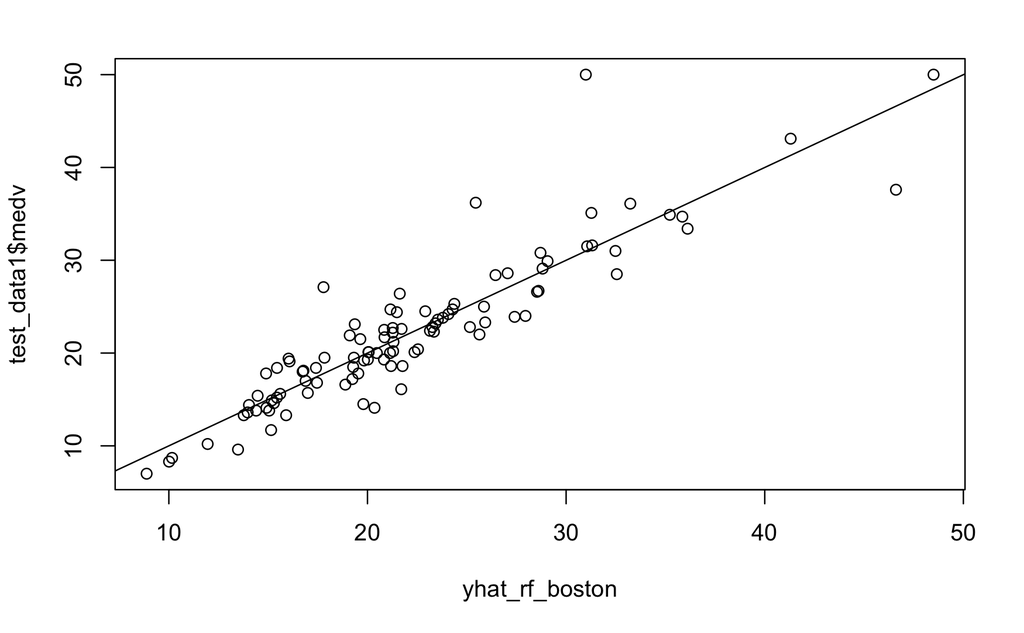

```r
yhat_rf_boston <- predict(rf_boston, test_data1)
plot(yhat_rf_boston, test_data1$medv)
abline(0, 1)
```

We can use the importance() function to see the importance of each variable

```r
importance(rf_boston)
```

```
          %IncMSE IncNodePurity
crim    14.651968    1526.81617
zn       3.916813     121.44971
indus    7.793855    1446.77915
chas     2.068979      55.04458
nox     21.621592    2082.71447
rm      44.194625   13135.60826
age     12.877532     765.34535
dis     17.989931    1941.99333
rad      6.083763     194.63475
tax     11.097106     485.93574
ptratio 11.258522    1397.53558
lstat   35.872071   12901.46793
```

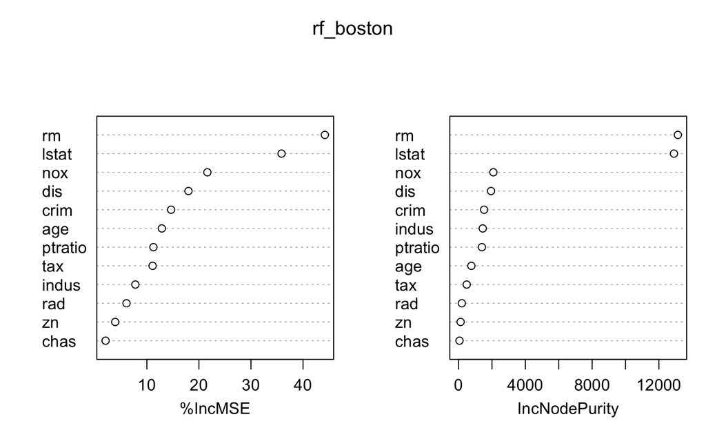

```r
varImpPlot(rf_boston)
```

## Another way to specify Bagging and Random Forest Models

We apply bagging/Random Forest using the rf method. There is one hyperparameter to tune by which is mtry (i.e. the number of variables randomly sampled at each split)

```r
tunegrid <- expand.grid(mtry = c(13))
```

Let us now look at model performance

```r
bag.boston
```

[output not shown]

```
Random Forest

407 samples
 12 predictor

No pre-processing
Resampling: Bootstrapped (25 reps)
Summary of sample sizes: 407, 407, 407, 407, 407, 407, ...
Resampling results:

  RMSE      Rsquared  MAE
  3.634089  0.860549  2.451022

Tuning parameter 'mtry' was held constant at a value of 13
```

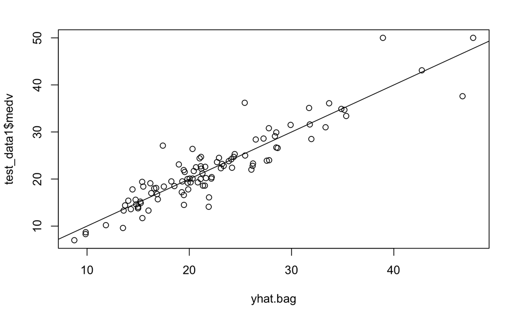

```r
yhat.bag <- predict(bag.boston$finalModel, newdata = test_data1)
plot(yhat.bag, test_data1$medv)
abline(0, 1)
```

This model fits pretty well. The number of trees can be changed.

```r
mean((yhat.bag - test_data1$medv)^2)
```

```
[1] 9.391357
```

[output not shown]

[output cut: 2 more lines]

For random forest, you will change the mtry variables using the same syntax.